# Project1_MATH237_F25_IanTroutt

Ethical Considerations:

- The Ames Housing data was collected from the years 2006 to 2010 from the City Assessor’s office in Ames Iowa by professor Dean de Cock from Truman State University. The procurement of this data set was primarily intended for teaching purposes with machine learning.
- Regarding ethical concerns, the data collected by the Assessor’s office is information routinely collected for taxation purposes, which is readily accessible to the public. Because the data was already available to the public, all the data was obtained legally, and no process was taken to obtain permission from the property owners to use their data. It is also important to note that any and all identifying information of the properties and their owners were not used, therefore protecting the identity of the individual.
- While there doesn’t appear to be any ethical issues behind the procurement of this data, some broader thoughts on how the data can be used may have some different ethical questions. Private companies using this dataset to maximize the most profit from selling a house by including the bare minimum of what is needed for a homebuyer could start a trend where there are less items in a home that can improve the quality of life for the homebuyer if they don’t have a significant contribution to the sale price of the house.
- On the other hand, data like this can be used for good intentions. Companies can see what homebuyers value most and use that information to tailor their needs and wants with future housing projects. Furthermore, using this dataset for teaching curriculums and educational purposes is a positive way to use it.
- Overall, ethical concerns of data can vary widely and is still a topic of great discussion with many gray areas. With data becoming such a valuable resource in our world, it is important for all researchers to consider these ethical questions and be able to make the right decisions as we pave the way in using these new technologies.

Citation:

De Cock, D. (2011). Ames, Iowa: Alternative to the Boston Housing Data as an End of Semester Regression Project. Journal of Statistics Education, 19(3). Retrieved from https://jse.amstat.org/v19n3/decock.pdf

This notebook aims to complete data wrangling of the housing dataset and see which features in utilities has the largest affect on house sale prices. the features that are considered as utilities in this study include:

Utilities (In General):

- Utilities: Type of utilities available

AllPub - All public Utilities (E,G,W,& S)

NoSewr - Electricity, Gas, and Water (Septic Tank)

NoSeWa - Electricity and Gas Only

ELO - Electricity only

- Heating: Type of heating

Floor - Floor Furnace

GasA - Gas forced warm air furnace

GasW - Gas hot water or steam heat

Grav - gravity furnace

OthW - Hot water or steam heat other than gas

Wall - Wall furnace

- HeatingQC: Heating quality and condition

Ex - Excellent

Gd - Good

TA - Average/Typical

Fa - Fair

Po - Poor

- Maybe use this → CentralAir: Central air conditioning
- Electrical: Electrical system

SBrkr - Standard Circuit Breakers & Romex

Fuse A - Fuse Box over 60 AMP and all Romex wiring (average)

Fuse F - 60 AMP Fuse Box and mostly Romex wiring (Fair)

Fuse P - 60 AMP Fuse Box and mostly knob & tube wiring (poor)

Mix - Mixed

```python
# Import all libraries needed for working with data.

import pandas as pd
import numpy as np
import matplotlib.pyplot as plt
import seaborn as sns
print("You have successfully imported your libraries!")
```

```
You have successfully imported your libraries!
```

```python
# Import the dataset from google drive into this notebook.
# Note: If you have issues with having a space in the script, just change your space to a "\". Instead of "My Drive", do "My\Drive".
from google.colab import drive
drive.mount('/content/drive')
print('You have successfully mounted your drive :)')
```

```
You have successfully mounted your drive :)
```

```python
# Load the data from google drive into this notebook.
data = pd.read_csv('/content/drive/My Drive/MATH237_CSUF/Project_1_M237/ames-housing-train.csv')
print('Good job, you loaded the dataset into this notebook!')
```

```
Good job, you loaded the dataset into this notebook!
```

```python
# Locate basic information from dataset.
print(f"Data shape (rows,columns): {data.shape}.")
print(f"The dataset consists of {data.shape[0]} samples and {data.shape[1]} features.")
print(f"The {data.shape[1]} features/columns include: {list(data.columns)}")
```

```
Data shape (rows,columns): (1460, 81).
The dataset consists of 1460 samples and 81 features.
The 81 features/columns include: ['Id', 'MSSubClass', 'MSZoning', 'LotFrontage', 'LotArea', 'Street', 'Alley', 'LotShape', 'LandContour', 'Utilities', 'LotConfig', 'LandSlope', 'Neighborhood', 'Condition1', 'Condition2', 'BldgType', 'HouseStyle', 'OverallQual', 'OverallCond', 'YearBuilt', 'YearRemod…
```

```python
# Observe all the different features in the housing dataset.
data.info()
```

```
<class 'pandas.core.frame.DataFrame'>
RangeIndex: 1460 entries, 0 to 1459
Data columns (total 81 columns):
 #   Column         Non-Null Count  Dtype
---  ------         --------------  -----
 0   Id             1460 non-null   int64
 1   MSSubClass     1460 non-null   int64
 2   MSZoning       1460 non-null   object
 3   LotFrontage    1201 non-null   float64
 4   LotArea        1460 non-null   int64
 5   Street         1460 non-null   object
 6   Alley          91 non-null     object
 7   LotShape       1460 non-null   object
 8   LandContour    1460 non-null   object
 9   Utilities      1460 non-null   object
```

[output cut: 73 more lines]

```python
# separate categorical and numerical data from eachother
# Below are the numerical features
numerical_features = data.select_dtypes(include=['int64','float64'])
categorical_features = data.select_dtypes(include=['object'])
print('Numerical features:')
print('')
numerical_features.info()
print('='*50)
print('')
print('')
print('Categorical features:')
categorical_features.info()
```

```
Numerical features:

<class 'pandas.core.frame.DataFrame'>
RangeIndex: 1460 entries, 0 to 1459
Data columns (total 38 columns):
 #   Column         Non-Null Count  Dtype
---  ------         --------------  -----
 0   Id             1460 non-null   int64
 1   MSSubClass     1460 non-null   int64
 2   LotFrontage    1201 non-null   float64
 3   LotArea        1460 non-null   int64
 4   OverallQual    1460 non-null   int64
 5   OverallCond    1460 non-null   int64
 6   YearBuilt      1460 non-null   int64
 7   YearRemodAdd   1460 non-null   int64
```

[output cut: 86 more lines]

```python
#-----Feature engineering portion-----
# Have SalePrice based on per squarefoot instead of entire property "LotArea". Included deletion of variables that have SalePrice at zero.
print(data.LotArea)
data['PricePerSqFtLand'] = data['SalePrice'] / data['LotArea'].replace(0, pd.NA)

#reassign SalePrice as SalePrice_raw to keep as variable. reassign name SalePrice to PricePerSqFtLand.
data['SalePrice_raw'] = data['SalePrice']
data['PricePerSqFtLand'] = data['SalePrice'] / data['LotArea'].replace(0, pd.NA)
```

```
0        8450
1        9600
2       11250
3        9550
4       14260
        ...
1455     7917
1456    13175
1457     9042
1458     9717
1459     9937
Name: LotArea, Length: 1460, dtype: int64
```

```python
# Exploring features regarding utilities
print(data.Utilities)
print('='*20)
print(data.Heating)
print('='*20)
print(data.HeatingQC)
print('='*20)
print(data.CentralAir)
print('='*20)
print(data.Electrical)
print('='*20)
```

```
0       AllPub
1       AllPub
2       AllPub
3       AllPub
4       AllPub
         ...
1455    AllPub
1456    AllPub
1457    AllPub
1458    AllPub
1459    AllPub
Name: Utilities, Length: 1460, dtype: object
====================
0       GasA
1       GasA
```

[output cut: 50 more lines]

```python
# Explore missing data in dataset.
print("Missing values by column:")
missing_counts = data.isnull().sum()
print(missing_counts)
```

```
Missing values by column:
Id                    0
MSSubClass            0
MSZoning              0
LotFrontage         259
LotArea               0
                   ...
SaleType              0
SaleCondition         0
SalePrice             0
PricePerSqFtLand      0
SalePrice_raw         0
Length: 83, dtype: int64
```

```python
# Find how much data is missing from each column
missing_counts = data.isnull().sum()
print(missing_counts[missing_counts > 0])
```

```
LotFrontage      259
Alley           1369
MasVnrType       872
MasVnrArea         8
BsmtQual          37
BsmtCond          37
BsmtExposure      38
BsmtFinType1      37
BsmtFinType2      38
Electrical         1
FireplaceQu      690
GarageType        81
GarageYrBlt       81
GarageFinish      81
GarageQual        81
GarageCond        81
PoolQC          1453
Fence           1179
MiscFeature     1406
dtype: int64
```

```python
# Examine the percent of data missing in each of the 83 features
print("MISSING DATA OVERVIEW:")
print("=" * 30)

complete_cases = len(data.dropna())
print(f"Total missing values: {missing_counts.sum()}")
print(f"Complete cases: {complete_cases} out of {len(data)}")

print(f"\nTotal observations: {len(data)}")
print(f"Complete cases (no missing data): {complete_cases}")
print(f"Percentage of complete cases: {complete_cases / len(data) * 100:.1f}%")

# Missing data by column (i.e. features also called variables)
print("\nMissing data by features:")
missing_summary = pd.DataFrame({
    'Missing_Count': data.isnull().sum(),
    'Missing_Percent': (data.isnull().sum() / len(data) * 100).round(1)
})
missing_summary = missing_summary[missing_summary['Missing_Count'] > 0]
print(missing_summary)
```

```
MISSING DATA OVERVIEW:
==============================
Total missing values: 7829
Complete cases: 0 out of 1460

Total observations: 1460
Complete cases (no missing data): 0
Percentage of complete cases: 0.0%

Missing data by features:
              Missing_Count  Missing_Percent
LotFrontage             259             17.7
Alley                  1369             93.8
MasVnrType              872             59.7
MasVnrArea                8              0.5
BsmtQual                 37              2.5
BsmtCond                 37              2.5
BsmtExposure             38              2.6
BsmtFinType1             37              2.5
BsmtFinType2             38              2.6
Electrical                1              0.1
FireplaceQu             690             47.3
GarageType               81              5.5
GarageYrBlt              81              5.5
GarageFinish             81              5.5
GarageQual               81              5.5
GarageCond               81              5.5
PoolQC                 1453             99.5
Fence                  1179             80.8
MiscFeature            1406             96.3
```

```python
# Investigate missing Electrical measurement data
print("\nThe samples that are missing Electrical records:\n")
electrical_missing = data[data['Electrical'].isnull()]
print(electrical_missing)
```

```
The samples that are missing Electrical records:

        Id  MSSubClass MSZoning  LotFrontage  LotArea Street Alley LotShape  \
1379  1380          80       RL         73.0     9735   Pave   NaN      Reg

     LandContour Utilities  ... Fence MiscFeature MiscVal MoSold YrSold  \
1379         Lvl    AllPub  ...   NaN         NaN       0      5   2008

     SaleType SaleCondition  SalePrice  PricePerSqFtLand  SalePrice_raw
1379       WD        Normal     167500         17.205958         167500

[1 rows x 83 columns]
```

```python
print("Listwise Deletion Results:")
print("=" * 35)
print(f"Original dataset: {len(data)} records")

# Listwise deletion only on 'Electrical'
data_complete = data[data['Electrical'].notna()]

print(f"After listwise deletion on 'Electrical': {len(data_complete)} records")
print(f"Lost: {len(data) - len(data_complete)} records ({(len(data) - len(data_complete))/len(data)*100:.1f}%)")

# Check if our sample is still representative (example with species)
print(f"\nelectrical distribution comparison:")
print(f"Original:")
original_electrical = data['Electrical'].value_counts(normalize=True).round(3)
print(original_electrical)

print(f"\nAfter deletion:")
complete_electrical = data_complete['Electrical'].value_counts(normalize=True).round(3)
print(complete_electrical)
```

```
Listwise Deletion Results:
===================================
Original dataset: 1460 records
After listwise deletion on 'Electrical': 1459 records
Lost: 1 records (0.1%)

electrical distribution comparison:
Original:
Electrical
SBrkr    0.914
FuseA    0.064
FuseF    0.019
FuseP    0.002
Mix      0.001
Name: proportion, dtype: float64

After deletion:
Electrical
SBrkr    0.914
FuseA    0.064
FuseF    0.019
FuseP    0.002
Mix      0.001
Name: proportion, dtype: float64
```

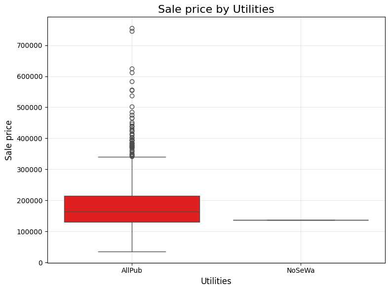

```python
# Visualization of Utilities vs Sale price in house with a box plot.

plt.figure(figsize=(8, 6))
sns.boxplot(data=data_complete, x='Utilities', y='SalePrice', hue='Utilities', palette=['red', 'blue'], legend=False)
plt.title('Sale price by Utilities', fontsize=16)
plt.xlabel('Utilities', fontsize=12)
plt.ylabel('Sale price', fontsize=12)
plt.grid(True, alpha=0.3)

plt.tight_layout()
plt.show()
```

```python
order = ['AllPub','NoSeWa']
for condition in order:
    if condition in data['Utilities'].unique():
        count = (data['Utilities'] == condition).sum()
        print(f"There are {count} records of condition: {condition}")
        print("="*20)
```

```
There are 1459 records of condition: AllPub
====================
There are 1 records of condition: NoSeWa
====================
```

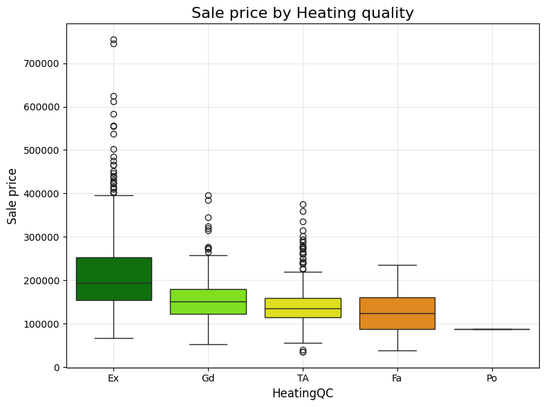

```python
# Visualization of HeatingQC vs Sale price in house with a box plot.

plt.figure(figsize=(8, 6))
sns.boxplot(data=data_complete, x='HeatingQC', y='SalePrice', hue='HeatingQC', palette=['green', 'chartreuse','yellow','darkorange','red'], legend=False)
plt.title('Sale price by Heating quality', fontsize=16)
plt.xlabel('HeatingQC', fontsize=12)
plt.ylabel('Sale price', fontsize=12)
plt.grid(True, alpha=0.3)

plt.tight_layout()
plt.show()
```

```python
order = ['Po', 'Fa', 'TA', 'Gd', 'Ex']
for condition in order:
    if condition in data['HeatingQC'].unique():
        count = (data['HeatingQC'] == condition).sum()
        print(f"There are {count} records of condition: {condition}")
        print("="*20)
```

```
There are 1 records of condition: Po
====================
There are 49 records of condition: Fa
====================
There are 428 records of condition: TA
====================
There are 241 records of condition: Gd
====================
There are 741 records of condition: Ex
====================
```

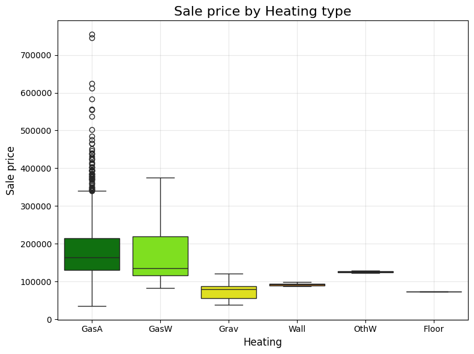

```python
# Visualization of Type of Heating vs Sale price of house with a box plot.

plt.figure(figsize=(8, 6))
sns.boxplot(data=data_complete, x='Heating', y='SalePrice', hue='Heating', palette=['green', 'chartreuse','yellow','darkorange','red','purple'], legend=False)
plt.title('Sale price by Heating type', fontsize=16)
plt.xlabel('Heating', fontsize=12)
plt.ylabel('Sale price', fontsize=12)
plt.grid(True, alpha=0.3)

plt.tight_layout()
plt.show()
```

```python
order = ['GasA', 'GasW', 'Grav', 'Wall', 'OthW','Floor']
for condition in order:
    if condition in data_complete['Heating'].unique():
        count = (data_complete['Heating'] == condition).sum()
        print(f"There are {count} records of condition: {condition}")
        print("="*20)
```

```
There are 1427 records of condition: GasA
====================
There are 18 records of condition: GasW
====================
There are 7 records of condition: Grav
====================
There are 4 records of condition: Wall
====================
There are 2 records of condition: OthW
====================
There are 1 records of condition: Floor
====================
```

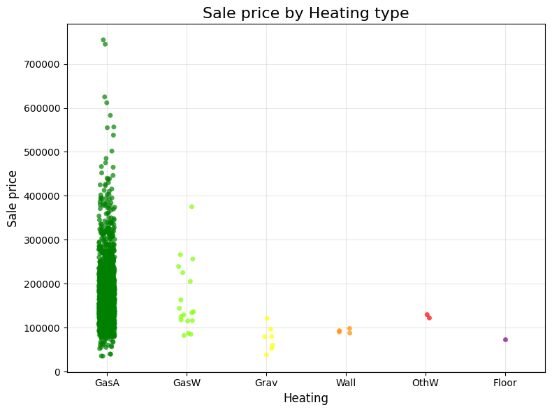

```python
# Visualization of Heating vs Sale price of house with a scatterplot.

plt.figure(figsize=(8, 6))

sns.stripplot(
    data=data_complete,
    x='Heating',
    y='SalePrice',
    hue='Heating',
    palette=['green', 'chartreuse', 'yellow', 'darkorange', 'red', 'purple'],
    dodge=False,
    alpha=0.7,
    size=5,
    jitter=True,   # adds horizontal spread so points don’t overlap
    legend=False
)

plt.title('Sale price by Heating type', fontsize=16)
plt.xlabel('Heating', fontsize=12)
plt.ylabel('Sale price', fontsize=12)
plt.grid(True, alpha=0.3)

plt.tight_layout()
plt.show()
```

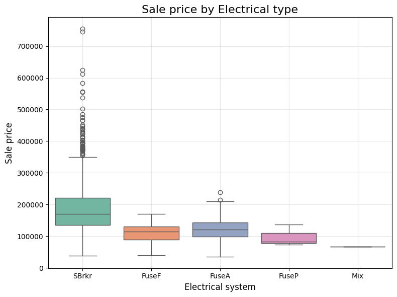

```python
# Visualization of Electrical vs Sale price of house with a box plot.

plt.figure(figsize=(8, 6))

sns.boxplot(
    data=data_complete,
    x='Electrical',
    y='SalePrice',
    hue='Electrical',  # optional: gives each electrical type its own color
    palette='Set2',    # you can also use your own color list
    legend=False
)

plt.title('Sale price by Electrical type', fontsize=16)
plt.xlabel('Electrical system', fontsize=12)
plt.ylabel('Sale price', fontsize=12)
plt.grid(True, alpha=0.3)

plt.tight_layout()
plt.show()
```

```python
order = ['SBrkr', 'FuseF', 'FuseA', 'FuseP', 'Mix']
for condition in order:
    if condition in data_complete['Electrical'].unique():
        count = (data_complete['Electrical'] == condition).sum()
        print(f"There are {count} records of condition: {condition}")
        print("="*20)
```

```
There are 1334 records of condition: SBrkr
====================
There are 27 records of condition: FuseF
====================
There are 94 records of condition: FuseA
====================
There are 3 records of condition: FuseP
====================
There are 1 records of condition: Mix
====================
```

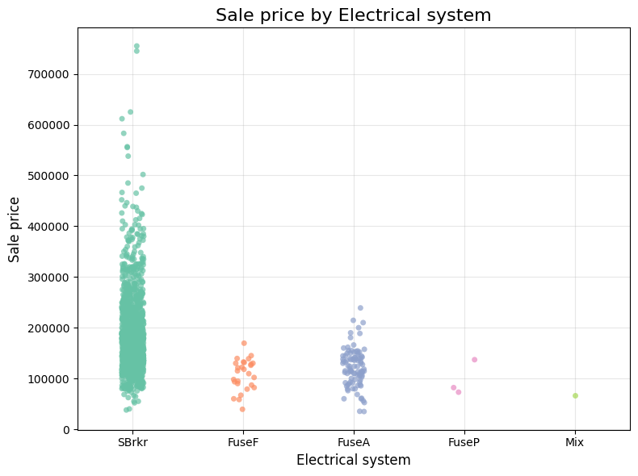

```python
# Visualization of Electrical vs Sale price of house with a scatterplot.

plt.figure(figsize=(8, 6))

sns.stripplot(
    data=data_complete,
    x='Electrical',
    y='SalePrice',
    hue='Electrical',   # optional: gives each type its own color
    palette='Set2',     # or use your custom color list
    dodge=False,
    alpha=0.7,
    size=5,
    jitter=True,        # spreads points horizontally for visibility
    legend=False
)

plt.title('Sale price by Electrical system', fontsize=16)
plt.xlabel('Electrical system', fontsize=12)
plt.ylabel('Sale price', fontsize=12)
plt.grid(True, alpha=0.3)

plt.tight_layout()
plt.show()
```

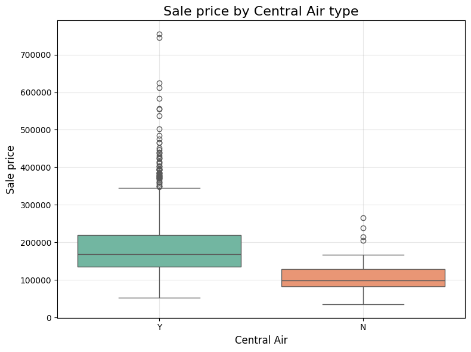

```python
# Visualization of CentralAir vs Sale price of house with a box plot.

plt.figure(figsize=(8, 6))

sns.boxplot(
    data=data_complete,
    x='CentralAir',
    y='SalePrice',
    hue='CentralAir',   # optional: gives each CentralAir type its own color
    palette='Set2',     # you can also use your own color list
    legend=False
)

plt.title('Sale price by Central Air type', fontsize=16)
plt.xlabel('Central Air', fontsize=12)
plt.ylabel('Sale price', fontsize=12)
plt.grid(True, alpha=0.3)

plt.tight_layout()
plt.show()
```

```python
order = ['Y', 'N']
for condition in order:
    if condition in data_complete['CentralAir'].unique():
        count = (data_complete['CentralAir'] == condition).sum()
        print(f"There are {count} records of condition: {condition}")
        print("="*20)
```

```
There are 1364 records of condition: Y
====================
There are 95 records of condition: N
====================
```

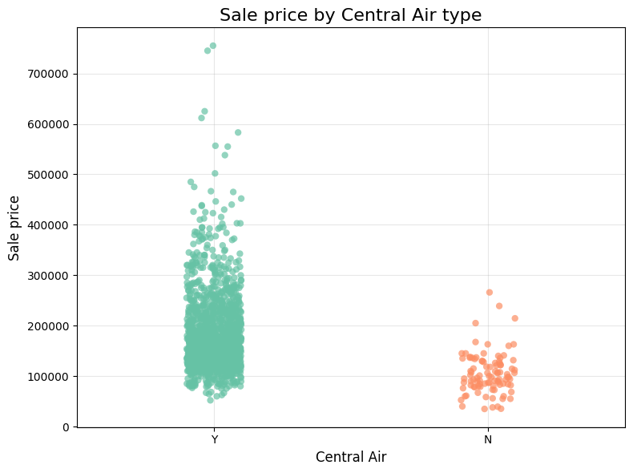

```python
# Visualization of CentralAir vs Sale price of house with a scatterplot.

plt.figure(figsize=(8, 6))

sns.stripplot(
    data=data_complete,
    x='CentralAir',
    y='SalePrice',
    hue='CentralAir',      # optional: colors by category
    palette='Set2',        # can customize colors
    dodge=False,
    alpha=0.7,
    size=6,
    jitter=True,           # spreads points horizontally for visibility
    legend=False
)

plt.title('Sale price by Central Air type', fontsize=16)
plt.xlabel('Central Air', fontsize=12)
plt.ylabel('Sale price', fontsize=12)
plt.grid(True, alpha=0.3)

plt.tight_layout()
plt.show()
```

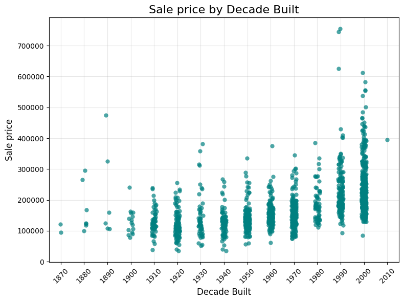

```python
# Visualization of Yearbuilt vs Sale price of house with a scatterplot.

data_complete['DecadeBuilt'] = (data_complete['YearBuilt'] // 10) * 10

plt.figure(figsize=(8, 6))

sns.stripplot(
    data=data_complete,
    x='DecadeBuilt',
    y='SalePrice',
    alpha=0.7,
    size=6,
    jitter=True,          # spreads points horizontally for visibility
    color='teal'
)

plt.title('Sale price by Decade Built', fontsize=16)
plt.xlabel('Decade Built', fontsize=12)
plt.ylabel('Sale price', fontsize=12)
plt.grid(True, alpha=0.3)
plt.xticks(rotation=45)

plt.tight_layout()
plt.show()
```

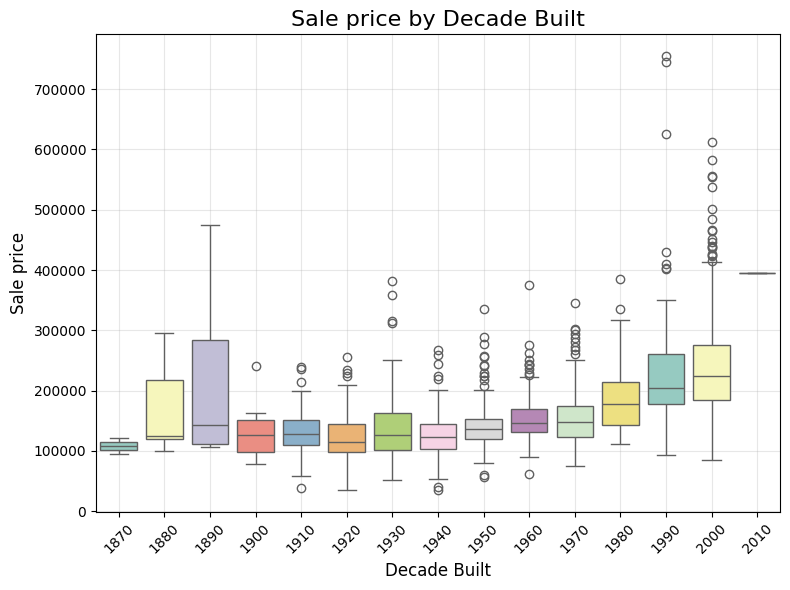

```python
# Visualization of Yearbuilt vs Sale price of house with a box plot.

data_complete['DecadeBuilt'] = (data_complete['YearBuilt'] // 10) * 10

plt.figure(figsize=(8, 6))

sns.boxplot(
    data=data_complete,
    x='DecadeBuilt',
    y='SalePrice',
    palette='Set3'  # you can customize colors
)

plt.title('Sale price by Decade Built', fontsize=16)
plt.xlabel('Decade Built', fontsize=12)
plt.ylabel('Sale price', fontsize=12)
plt.grid(True, alpha=0.3)
plt.xticks(rotation=45)

plt.tight_layout()
plt.show()
```

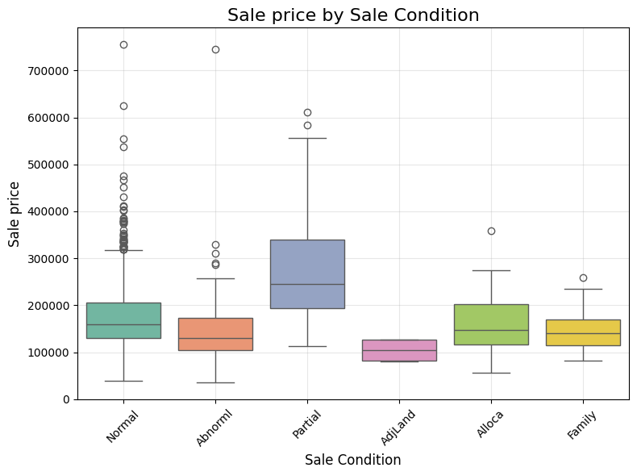

```python
# Visualization of SaleCondition vs Sale price of house with a scatterplot.

plt.figure(figsize=(8, 6))

sns.boxplot(
    data=data_complete,
    x='SaleCondition',
    y='SalePrice',
    hue='SaleCondition',  # optional: colors by category
    palette='Set2',       # customize colors if desired
    legend=False
)

plt.title('Sale price by Sale Condition', fontsize=16)
plt.xlabel('Sale Condition', fontsize=12)
plt.ylabel('Sale price', fontsize=12)
plt.grid(True, alpha=0.3)
plt.xticks(rotation=45)  # rotates x-axis labels for readability if many categories

plt.tight_layout()
plt.show()
```

What does our data tell us about each feature and how it relates to Saleprice of a home? Let's break it down.

Utilities: There isn't much data to compare within this feature to make any groundbreaking findings.

Heating Type: There isn't enough data in observations other than GasA, this may only tell us what the more common types of Heating Types are used rather than what has a higher correlation with higher home sale prices.

Sale Condition: The data suggests that the partial observation tends to have a higher sale price than the other homes.

In Conclusion, I prepared the data for visualization after exploration of the housing dataset and carried out numerous visualizations to test.

```python
# Convert this notebook to HTML
!jupyter nbconvert --to html --no-prompt "/content/drive/My Drive/MATH237_CSUF/Project_1_M237/Project1_MATH237_F25_IanTroutt.ipynb" --output Project1_MATH237_F25_IanTroutt
```

```
[NbConvertApp] Converting notebook /content/drive/My Drive/MATH237_CSUF/Project_1_M237/Project1_MATH237_F25_IanTroutt.ipynb to html
[NbConvertApp] Writing 351665 bytes to /content/drive/My Drive/MATH237_CSUF/Project_1_M237/Project1_MATH237_F25_IanTroutt.html
```